# NBA Usage Rate & True Shooting %: Predicting 2019-2020 PER

## Create Ridge Regression Model

```r
y.scaled = scale(NBAtrainData$PER)
X.scaled = scale(as.matrix(NBAtrainData[,-1]))

#Ridge Regression
lambda = seq(100, 110, by=0.01)
Ridge = lm.ridge(PER~.,data=NBAtrainData, lambda = lambda)
which(Ridge$GCV == min(Ridge$GCV))
```

```
## 100.00
##      1
```

```r
summary(Ridge)
```

```
##        Length Class  Mode
## coef   11011  -none- numeric
## scales    11  -none- numeric
## Inter      1  -none- numeric
## lambda  1001  -none- numeric
## ym         1  -none- numeric
## xm        11  -none- numeric
## GCV     1001  -none- numeric
## kHKB       1  -none- numeric
## kLW        1  -none- numeric
```

```r
#For scaled predictors
round(Ridge$coef[,which(Ridge$GCV == min(Ridge$GCV))], 4)
```

```
##      GP     MPG      TS     AST      TO     USG     ORR     DRR    REBR      VA     EWA
## -0.1428  0.1729  0.9945  0.3073 -0.2689  1.1916  0.6596  0.3080  0.4728  1.0540  1.0519
```

```r
#On original scale
round(coef(Ridge)[which(Ridge$GCV == min(Ridge$GCV)),],4)
```

```
##              GP     MPG      TS     AST      TO     USG     ORR     DRR    REBR      VA     EWA
## -4.8919 -0.0102  0.0253 20.9514  0.0408 -0.1191  0.2177  0.1792  0.0479  0.0997  0.0070  0.2091
```

## Create Lasso Regression Model

```r
lasso.cv=cv.glmnet(as.matrix(NBAtrainData[,-1]),NBAtrainData$PER,alpha=1,nfolds=10)
lasso = glmnet(as.matrix(NBAtrainData[,-1]),NBAtrainData$PER, alpha = 1, nlambda = 100)
lasso.cv$lambda.min
```

```
## [1] 0.009322263
```

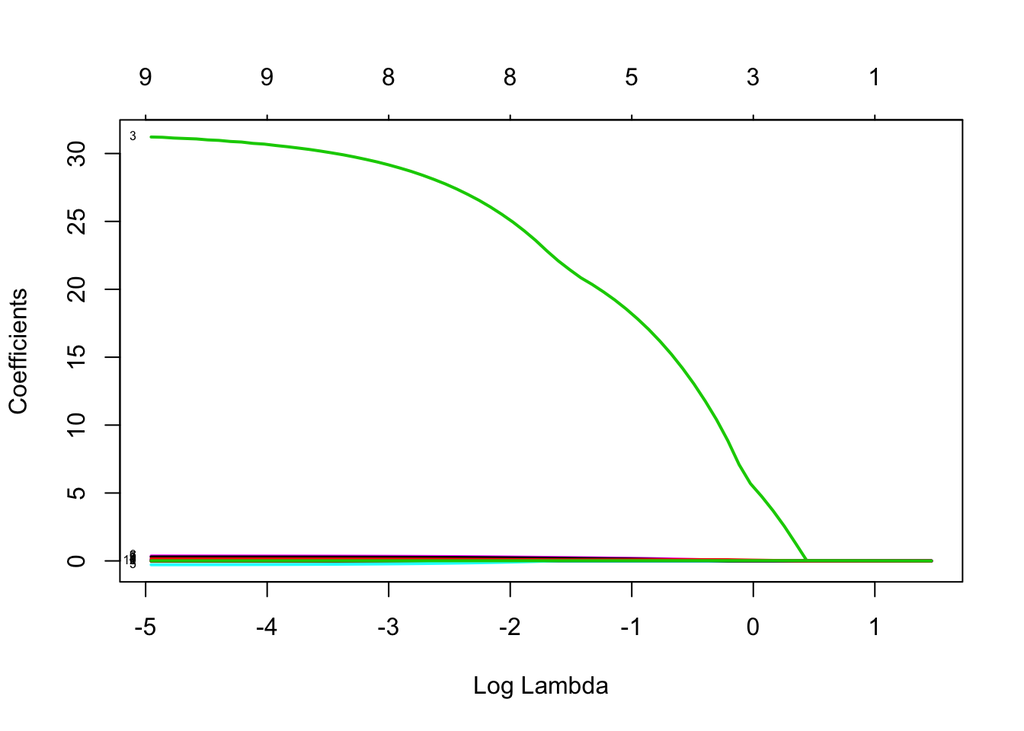

```r
plot(lasso,xvar="lambda",label=TRUE,lwd=2)
```

```r
#abline(v=log(lasso$lambda.min),col='black',lty = 2,lwd=2)

coef(lasso,s=lasso.cv$lambda.min)
```

```
## 12 x 1 sparse Matrix of class "dgCMatrix"
##                         1
## (Intercept) -11.478822967
## GP           -0.019055474
## MPG           0.003289843
## TS           31.105701743
## AST           0.090862678
## TO           -0.281264176
## USG           0.360204681
## ORR           0.294183353
## DRR           .
## REBR          0.146841254
## VA            0.011330163
## EWA           .
```

## Create Elastic Net Regression Model

```r
elastic.cv=cv.glmnet(as.matrix(NBAtrainData[,-11]),NBAtrainData$PER,alpha=0.5,nfolds=10)
elastic = glmnet(as.matrix(NBAtrainData[,-1]), NBAtrainData$PER, alpha = 0.5, nlambda = 100)
elastic.cv$lambda.min
```

```
## [1] 0.108264
```

```r
coef(elastic,s=elastic.cv$lambda.min)
```

```
## 12 x 1 sparse Matrix of class "dgCMatrix"
##                        1
## (Intercept) -9.553645530
## GP          -0.014196385
## MPG          .
## TS          28.190789021
## AST          0.067163271
## TO          -0.200014269
## USG          0.321722819
## ORR          0.257115192
## DRR          .
## REBR         0.132142584
## VA           0.006193142
## EWA          0.194568602
```

9 Variables Selected for Elastic Net Regression: GP, True Shoot, Assist Ratio, TO Ratio, Usage Rate, Offensive Rebound Rate, Rebound Rate, Value Added, Wins Added

## Predict Using All Regression Models

```r
full=predict(full_standard_linear_model,ALLNBAtestData)
reduced=predict(reduced_standard_linear_model,ALLNBAtestData)
reduced2=predict(reduced_standard_linear_model_2,ALLNBAtestData)
reduced3=predict(reduced_standard_linear_model_3,ALLNBAtestData)



step=predict(step_fwd,ALLNBAtestData)

ridge=cbind(1,as.matrix(NBAtestData[,-1]))%*%coef(Ridge)[which(Ridge$GCV == min(Ridge$GCV)),]
#Alternate method:
#ridge=scale(as.matrix(testData[,-13]),center=mod4$xm,scale=mod4$scales) %*%
#        mod4$coef[,which(mod4$GCV == min(mod4$GCV))]+mod4$ym
#If response had been scaled separately before fitting the model:
#ridge=ridge*attr(y.scaled,"scaled:scale")+attr(y.scaled,"scaled:center")
modlasso=lm(PER~.,data=NBAtrainData)
lasso=predict(modlasso,NBAtestData)
elastic_pred=as.vector(predict(elastic,as.matrix(NBAtestData[,-1]),s=elastic.cv$lambda.min))
#If predictors had been scaled separately before fitting the model:
#Xtest.scl=scale(testData[,-13],center=attr(X.scaled,"scaled:center"),
#                scale=attr(X.scaled,"scaled:scale"))
#elastic=predict(mod6,Xtest.scl,s=mod6.cv$lambda.min)
preds_names=data.frame(PLAYER=ALLNBAtestData$PLAYER,PER=ALLNBAtestData$PER,full,reduced,step,ridge,lasso,elastic_pred)
preds=data.frame(PER=ALLNBAtestData$PER,full,reduced,reduced2, reduced3, step,ridge,lasso,elastic_pred)
preds_names
```

```
##                PLAYER   PER      full   reduced      step     ridge     lasso elastic_pred
## 39      Blake Griffin 21.02 21.996629 22.446451 22.017300 12.086689 11.829262    12.015134
## 169        Jeremy Lin 13.58 13.823826 14.200407 13.871029 12.135994 12.193010    12.425606
## 287     Mario Hezonja 10.88 10.393819 11.333831 10.422088 21.741313 22.821128    22.527645
## 239      Luke Kennard 11.99 12.162649 12.801827 12.184850  9.795727  8.774367     9.131354
## 46       Jimmy Butler 20.29 20.126947 20.092293 20.099913 10.470464  9.075648     9.635314
## 327       Abdel Nader  8.83  8.586267 10.270816  8.669699 12.608184 12.416486    12.553031
## 135   Kelly Oubre Jr. 15.22 15.194963 15.642534 15.199612  9.424095  8.462640     8.663766
## 219     Bruno Caboclo 12.41 13.028854 13.759814 13.001689  9.117694  8.197900     8.579589
## 127      Delon Wright 15.54 13.790897 12.968504 13.802256 16.215980 17.134274    16.615983
## 149     Marcus Morris 14.28 14.490933 14.099865 14.472193 11.005741 10.135762    10.423021
## 278  Juan Hernangomez 11.03 11.406615 11.310063 11.410100 15.606923 16.504794    16.219650
## 355    Isaiah Briscoe  6.74  8.120325  8.859391  8.163048  9.496148  8.233915     8.686966
## 334    Jerryd Bayless  8.58  9.738051  9.087667  9.745648 16.347014 15.110822    15.375674
## 256    Doug McDermott 11.64 12.193010 13.383716 12.221828 10.717374  9.620404    10.092446
```

[output cut: 22 more lines]

```r
preds
```

```
##       PER      full   reduced  reduced2  reduced3      step     ridge     lasso elastic_pred
## 39  21.02 21.996629 22.446451 22.275893 22.318243 22.017300 12.086689 11.829262    12.015134
## 169 13.58 13.823826 14.200407 17.083991 17.030432 13.871029 12.135994 12.193010    12.425606
## 287 10.88 10.393819 11.333831 11.716826 11.916561 10.422088 21.741313 22.821128    22.527645
## 239 11.99 12.162649 12.801827 14.203544 14.215327 12.184850  9.795727  8.774367     9.131354
## 46  20.29 20.126947 20.092293 17.720000 17.644527 20.099913 10.470464  9.075648     9.635314
## 327  8.83  8.586267 10.270816  9.714141 10.041615  8.669699 12.608184 12.416486    12.553031
## 135 15.22 15.194963 15.642534 16.222365 16.557631 15.199612  9.424095  8.462640     8.663766
## 219 12.41 13.028854 13.759814 13.696823 13.405567 13.001689  9.117694  8.197900     8.579589
## 127 15.54 13.790897 12.968504 11.623628 11.568726 13.802256 16.215980 17.134274    16.615983
## 149 14.28 14.490933 14.099865 15.369463 15.671783 14.472193 11.005741 10.135762    10.423021
## 278 11.03 11.406615 11.310063 11.994374 12.150175 11.410100 15.606923 16.504794    16.219650
## 355  6.74  8.120325  8.859391  6.780393  6.308127  8.163048  9.496148  8.233915     8.686966
## 334  8.58  9.738051  9.087667  7.322222  6.884212  9.745648 16.347014 15.110822    15.375674
## 256 11.64 12.193010 13.383716 16.156846 16.318453 12.221828 10.717374  9.620404    10.092446
```

[output cut: 22 more lines]

## Compare Means Square Prediction Error (MSPE)

```r
#MEAN SQUARE PREDICTION ERROR
#MSPE
sapply(preds[,-1],function(x){mean((x-ALLNBAtestData$PER)^2)})
```

```
##         full      reduced     reduced2     reduced3         step        ridge        lasso elastic_pred
##    0.4481178    1.5906311    6.7739425    6.7866928    0.4540131   33.0672028   38.1052345   36.1813689
```

```r
preds_final_models=data.frame(PLAYER=ALLNBAtestData$PLAYER,PER=ALLNBAtestData$PER, reduced3, step)
preds_final_models
```

```
##                PLAYER   PER  reduced3      step
## 39      Blake Griffin 21.02 22.318243 22.017300
## 169        Jeremy Lin 13.58 17.030432 13.871029
## 287     Mario Hezonja 10.88 11.916561 10.422088
## 239      Luke Kennard 11.99 14.215327 12.184850
## 46       Jimmy Butler 20.29 17.644527 20.099913
## 327       Abdel Nader  8.83 10.041615  8.669699
## 135   Kelly Oubre Jr. 15.22 16.557631 15.199612
## 219     Bruno Caboclo 12.41 13.405567 13.001689
## 127      Delon Wright 15.54 11.568726 13.802256
## 149     Marcus Morris 14.28 15.671783 14.472193
## 278  Juan Hernangomez 11.03 12.150175 11.410100
## 355    Isaiah Briscoe  6.74  6.308127  8.163048
## 334    Jerryd Bayless  8.58  6.884212  9.745648
## 256    Doug McDermott 11.64 16.318453 12.221828
```

[output cut: 22 more lines]

## Predict PER for James Harden and Lebron James using Reduced 3 Model

```r
#USING REDUCED 3 REGRESSION MODEL, PREDICT LEBRON JAMES AND JAMES HARDEN PER


JAMES_HARDEN=data.frame(USG=40.8, TS= .616 )
LEBRON_JAMES=data.frame(USG=32.6, TS= .588 )
predict(reduced_standard_linear_model_3,JAMES_HARDEN,type="response")
```

```
##        1
## 29.79074
```

```r
predict(reduced_standard_linear_model_3,LEBRON_JAMES,type="response")
```

```
##        1
## 23.66057
```

```r
#confint(reduced_standard_linear_model_3,"TS",level=.75)
#confint(reduced_standard_linear_model_3,"USG",level=.75)
```

Given the True Shooting Percentage and Usage Rate, my model predicted that James Harden would have a 29.79074 PER. He actually had a PER of 30.62 last year.

Given the True Shooting Percentage and Usage Rate, my model predicted that Lebron James would have a 23.66057 PER. He actually had a PER of 25.64 last year.